# Project: Investigate a No Show Appointment Dataset

- Introduction
- Data Wrangling
- Exploratory Data Analysis
- Conclusions

## Introduction

### Dataset Description

> Rise in health-related issues has made it critical that everyone has easy access to health-care services. However, it has been discovered that despite providing access, patients may or may not show up for their appointments, resulting in hospital operating losses as salaries are paid whether or not patients visit the hospitals as expected. This report attempts to analyze the reasons why patients do not show up for appointments after scheduling them, as well as provide potential solutions that hospitals can consider in order to increase revenue. This dataset collects information from 100,000 plus medical appointments in Brazil and is focused on the question of whether or not patients show up for their appointment. A number of characteristics about the patient are included in each row. The dataset is made up of 14 unique variables which we are going to use for our analysis.

### Variables in this Dataset

1) "Scheduled Day" = tells us on what day the patient set up their appointment.

2) "Neighborhood" = indicates the location of the hospital.

3) "Scholarship" = indicates whether or not the patient is enrolled in the Brasilian welfare program "Bolsa Família".

4) "Patient ID" = indicates the patient's number used in indentiification at the hospital.

5) "Appointment ID" = indicates the appointment number given to each patient.

6) "Gender" = indicates whether the patient is a Male or Female.

7) "Appointment Day" = indicates the patient's date of appointment.

8) "Age" = indicates the age of the patient.

NB//: 1) No Show variable will be used as our dependent variable while the others will be used as independent variables

```
2) For the last column: it says ‘No’ if the patient showed up to their appointment, and ‘Yes’ if they did not show up.
```

### Question(s) for Analysis

So we will try answering the following questions below:

1) Comparing the percentage of people that showed up to those that didn't?

2) Why are people not showing up for their appointments?

3) Is scholarship a major determinant in affecting the presence of the patient at the hospital?

4) Is there any significant relationship between distance from patient neighbourhood to the hospital and their showing up for appointments?

5) Any impact on the ability of a patient to show up for their appointment using time difference between a patient schedule date and his appointment date?

```python
# import statements for all packages

# For Data analysis

import pandas as pd

import numpy as np



# For data Visualization

import matplotlib.pyplot as plt

import seaborn as sns

%matplotlib inline
```

```python
# Upgrade pandas to use dataframe.explode() function.

!pip install --upgrade pandas==0.25.0
```

[output not shown]

[output cut: 849 more lines]

[output not shown]

[output not shown]

[output not shown]

[output not shown]

[output cut: 330 more lines]

[output not shown]

## Data Wrangling

In this section of the report, we are going to perform the following tasks:

```
1) load in the data.

2) check for cleanliness and orderliness.

3) trim the dataset.

4) clean the dataset for analysis.
```

### General Properties

I am going to avoid performing too many operations in each cell. I am going to Create cells freely to explore my data.

```python
# Loading my data
df = pd.read_csv("C:\\Users\\pharmacy1\\Downloads\\noshowappointments-kagglev2-may-2016.csv")

#Performing operations to inspect few columns in the dataset

df.head()
```

[output not shown]

[output cut: 1462 more lines]

[output not shown]

|  | PatientId | AppointmentID | Gender | ScheduledDay | AppointmentDay | Age | Neighbourhood | Scholarship | Hipertension | Diabetes | Alcoholism | Handcap | SMS_received | No-show |
| --- | --- | --- | --- | --- | --- | --- | --- | --- | --- | --- | --- | --- | --- | --- |
| 0 | 2.987250e+13 | 5642903 | F | 2016-04-29T18:38:08Z | 2016-04-29T00:00:00Z | 62 | JARDIM DA PENHA | 0 | 1 | 0 | 0 | 0 | 0 | No |
| 1 | 5.589978e+14 | 5642503 | M | 2016-04-29T16:08:27Z | 2016-04-29T00:00:00Z | 56 | JARDIM DA PENHA | 0 | 0 | 0 | 0 | 0 | 0 | No |
| 2 | 4.262962e+12 | 5642549 | F | 2016-04-29T16:19:04Z | 2016-04-29T00:00:00Z | 62 | MATA DA PRAIA | 0 | 0 | 0 | 0 | 0 | 0 | No |
| 3 | 8.679512e+11 | 5642828 | F | 2016-04-29T17:29:31Z | 2016-04-29T00:00:00Z | 8 | PONTAL DE CAMBURI | 0 | 0 | 0 | 0 | 0 | 0 | No |
| 4 | 8.841186e+12 | 5642494 | F | 2016-04-29T16:07:23Z | 2016-04-29T00:00:00Z | 56 | JARDIM DA PENHA | 0 | 1 | 1 | 0 | 0 | 0 | No |

```python
# getting information on the characteristices of each attributes in the dataset

df.info()
```

```
<class 'pandas.core.frame.DataFrame'>
RangeIndex: 110527 entries, 0 to 110526
Data columns (total 14 columns):
 #   Column          Non-Null Count   Dtype
---  ------          --------------   -----
 0   PatientId       110527 non-null  float64
 1   AppointmentID   110527 non-null  int64
 2   Gender          110527 non-null  object
 3   ScheduledDay    110527 non-null  object
 4   AppointmentDay  110527 non-null  object
 5   Age             110527 non-null  int64
 6   Neighbourhood   110527 non-null  object
 7   Scholarship     110527 non-null  int64
 8   Hipertension    110527 non-null  int64
 9   Diabetes        110527 non-null  int64
 10  Alcoholism      110527 non-null  int64
 11  Handcap         110527 non-null  int64
 12  SMS_received    110527 non-null  int64
 13  No-show         110527 non-null  object
dtypes: float64(1), int64(8), object(5)
memory usage: 11.8+ MB
```

```python
#checking the size of the dataset

df.shape
```

```
(110527, 14)
```

# The Dataset I am working on possess:

```
1) 110,527 records/rows

2) 14 Fields/Columns
```

```python
# Checking the statistical values of the dataset

df.describe()
```

|  | PatientId | AppointmentID | Age | Scholarship | Hipertension | Diabetes | Alcoholism | Handcap | SMS_received |
| --- | --- | --- | --- | --- | --- | --- | --- | --- | --- |
| count | 1.105270e+05 | 1.105270e+05 | 110527.000000 | 110527.000000 | 110527.000000 | 110527.000000 | 110527.000000 | 110527.000000 | 110527.000000 |
| mean | 1.474963e+14 | 5.675305e+06 | 37.088874 | 0.098266 | 0.197246 | 0.071865 | 0.030400 | 0.022248 | 0.321026 |
| std | 2.560949e+14 | 7.129575e+04 | 23.110205 | 0.297675 | 0.397921 | 0.258265 | 0.171686 | 0.161543 | 0.466873 |
| min | 3.921784e+04 | 5.030230e+06 | -1.000000 | 0.000000 | 0.000000 | 0.000000 | 0.000000 | 0.000000 | 0.000000 |
| 25% | 4.172614e+12 | 5.640286e+06 | 18.000000 | 0.000000 | 0.000000 | 0.000000 | 0.000000 | 0.000000 | 0.000000 |
| 50% | 3.173184e+13 | 5.680573e+06 | 37.000000 | 0.000000 | 0.000000 | 0.000000 | 0.000000 | 0.000000 | 0.000000 |
| 75% | 9.439172e+13 | 5.725524e+06 | 55.000000 | 0.000000 | 0.000000 | 0.000000 | 0.000000 | 0.000000 | 1.000000 |
| max | 9.999816e+14 | 5.790484e+06 | 115.000000 | 1.000000 | 1.000000 | 1.000000 | 1.000000 | 4.000000 | 1.000000 |

```python
# Checking Columns for missing value

df.isnull().sum().any()
```

```
False
```

```python
# Checking row for missing value

df.isnull().any(axis = 1).sum()
```

```
0
```

```python
#checking number of unique characters

df.nunique().sum()
```

```
276606
```

```python
#print number of duplicates

print(df.duplicated().sum())
```

```
0
```

# Important Information

I have gone through the entire dataset to check for the number of columns, number of rows, presence of duplicated value, presence of missing values, the statistical figure of the dataset and the number of Unique characters.

### Data Cleaning

I am going to keep you informed on the steps taken in my investigation. Following every code cell, or every set of related code cells, with a markdown cell to describe what was found in the preceding cell(s).

## Prepaing the data and identifying irregularities

```python
# Checking the data type of each attributes and making sure they are in the right format needed for analysis

df.dtypes
```

```
PatientId         float64
AppointmentID       int64
Gender             object
ScheduledDay       object
AppointmentDay     object
Age                 int64
Neighbourhood      object
Scholarship         int64
Hipertension        int64
Diabetes            int64
Alcoholism          int64
Handcap             int64
SMS_received        int64
No-show            object
dtype: object
```

The Following listed below are not in the right format:

```
1) Patient Id

2) Appointment ID

3) Scheduled Day

4) Appointment Day


I will need to convert each of the listed datatype to its correct datatype for this project analysis
```

```python
# Converting Appointment Day and Scheduled day to its correct data type

to_date = ['AppointmentDay', 'ScheduledDay']

for dat in to_date:

    df[dat] = df[dat].apply(pd.to_datetime).dt.date

    df[dat] = df[dat].apply(pd.to_datetime)
```

```python
# Converting Patient Id and Appointment ID to its correct data type

to_obj = ['PatientId', 'AppointmentID']

for alpha in to_obj:

    df[alpha] = df[alpha].astype('str')
```

```python
# Checking the information of the data set

df.info()
```

```
<class 'pandas.core.frame.DataFrame'>
RangeIndex: 110527 entries, 0 to 110526
Data columns (total 14 columns):
 #   Column          Non-Null Count   Dtype
---  ------          --------------   -----
 0   PatientId       110527 non-null  object
 1   AppointmentID   110527 non-null  object
 2   Gender          110527 non-null  object
 3   ScheduledDay    110527 non-null  datetime64[ns]
 4   AppointmentDay  110527 non-null  datetime64[ns]
 5   Age             110527 non-null  int64
 6   Neighbourhood   110527 non-null  object
 7   Scholarship     110527 non-null  int64
 8   Hipertension    110527 non-null  int64
 9   Diabetes        110527 non-null  int64
 10  Alcoholism      110527 non-null  int64
 11  Handcap         110527 non-null  int64
 12  SMS_received    110527 non-null  int64
 13  No-show         110527 non-null  object
dtypes: datetime64[ns](2), int64(7), object(5)
memory usage: 11.8+ MB
```

```python
# Rechecking the statistical properties of all the numeric variables

df.describe()
```

|  | Age | Scholarship | Hipertension | Diabetes | Alcoholism | Handcap | SMS_received |
| --- | --- | --- | --- | --- | --- | --- | --- |
| count | 110527.000000 | 110527.000000 | 110527.000000 | 110527.000000 | 110527.000000 | 110527.000000 | 110527.000000 |
| mean | 37.088874 | 0.098266 | 0.197246 | 0.071865 | 0.030400 | 0.022248 | 0.321026 |
| std | 23.110205 | 0.297675 | 0.397921 | 0.258265 | 0.171686 | 0.161543 | 0.466873 |
| min | -1.000000 | 0.000000 | 0.000000 | 0.000000 | 0.000000 | 0.000000 | 0.000000 |
| 25% | 18.000000 | 0.000000 | 0.000000 | 0.000000 | 0.000000 | 0.000000 | 0.000000 |
| 50% | 37.000000 | 0.000000 | 0.000000 | 0.000000 | 0.000000 | 0.000000 | 0.000000 |
| 75% | 55.000000 | 0.000000 | 0.000000 | 0.000000 | 0.000000 | 0.000000 | 1.000000 |
| max | 115.000000 | 1.000000 | 1.000000 | 1.000000 | 1.000000 | 4.000000 | 1.000000 |

Evaluating the dataset using the descriptive statistical value shows that the age variable possess a minimium value of -1 which is an unusual figure.

I am going to drop the roll that possess the unusual negative value in the Age variable.

Every other columns looks okay

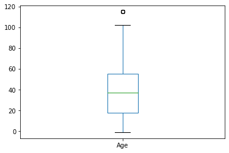

```python
df['Age'].plot(kind = 'box');
```

```python
#115 is the oldest age according to the box plot and that seems like a realistic age for a human being

# Implementing a function statement to rectify the discrepancy

def outlier(df, age):

    q1 = df['Age'].quantile(0.25)

    q3 = df['Age'].quantile(0.75)

    QR = q3 - q1

    df = df.loc[~((df['Age'] < (q1 -1.5 * QR))| (df['Age'] < (q3 + 1.5 * QR))),]

    return df

outlier(df, 'Age')
```

|  | PatientId | AppointmentID | Gender | ScheduledDay | AppointmentDay | Age | Neighbourhood | Scholarship | Hipertension | Diabetes | Alcoholism | Handcap | SMS_received | No-show |
| --- | --- | --- | --- | --- | --- | --- | --- | --- | --- | --- | --- | --- | --- | --- |
| 63912 | 31963211613981.0 | 5700278 | F | 2016-05-16 | 2016-05-19 | 115 | ANDORINHAS | 0 | 0 | 0 | 0 | 1 | 0 | Yes |
| 63915 | 31963211613981.0 | 5700279 | F | 2016-05-16 | 2016-05-19 | 115 | ANDORINHAS | 0 | 0 | 0 | 0 | 1 | 0 | Yes |
| 68127 | 31963211613981.0 | 5562812 | F | 2016-04-08 | 2016-05-16 | 115 | ANDORINHAS | 0 | 0 | 0 | 0 | 1 | 0 | Yes |
| 76284 | 31963211613981.0 | 5744037 | F | 2016-05-30 | 2016-05-30 | 115 | ANDORINHAS | 0 | 0 | 0 | 0 | 1 | 0 | No |
| 97666 | 748234579244724.0 | 5717451 | F | 2016-05-19 | 2016-06-03 | 115 | SÃO JOSÉ | 0 | 1 | 0 | 0 | 0 | 1 | No |

```python
# Query the Age variable

df.query('Age == -1')
```

|  | PatientId | AppointmentID | Gender | ScheduledDay | AppointmentDay | Age | Neighbourhood | Scholarship | Hipertension | Diabetes | Alcoholism | Handcap | SMS_received | No-show |
| --- | --- | --- | --- | --- | --- | --- | --- | --- | --- | --- | --- | --- | --- | --- |
| 99832 | 465943158731293.0 | 5775010 | F | 2016-06-06 | 2016-06-06 | -1 | ROMÃO | 0 | 0 | 0 | 0 | 0 | 0 | No |

```python
#Dropping the above variable

df.drop(df.query('Age == -1').index, inplace = True)
```

```python
# Checking to confirm the negative age variable isn't in our data set

df.describe()
```

|  | Age | Scholarship | Hipertension | Diabetes | Alcoholism | Handcap | SMS_received |
| --- | --- | --- | --- | --- | --- | --- | --- |
| count | 110526.000000 | 110526.000000 | 110526.000000 | 110526.000000 | 110526.000000 | 110526.000000 | 110526.000000 |
| mean | 37.089219 | 0.098266 | 0.197248 | 0.071865 | 0.030400 | 0.022248 | 0.321029 |
| std | 23.110026 | 0.297676 | 0.397923 | 0.258266 | 0.171686 | 0.161543 | 0.466874 |
| min | 0.000000 | 0.000000 | 0.000000 | 0.000000 | 0.000000 | 0.000000 | 0.000000 |
| 25% | 18.000000 | 0.000000 | 0.000000 | 0.000000 | 0.000000 | 0.000000 | 0.000000 |
| 50% | 37.000000 | 0.000000 | 0.000000 | 0.000000 | 0.000000 | 0.000000 | 0.000000 |
| 75% | 55.000000 | 0.000000 | 0.000000 | 0.000000 | 0.000000 | 0.000000 | 1.000000 |
| max | 115.000000 | 1.000000 | 1.000000 | 1.000000 | 1.000000 | 4.000000 | 1.000000 |

```python
df.head(1)
```

|  | PatientId | AppointmentID | Gender | ScheduledDay | AppointmentDay | Age | Neighbourhood | Scholarship | Hipertension | Diabetes | Alcoholism | Handcap | SMS_received | No-show |
| --- | --- | --- | --- | --- | --- | --- | --- | --- | --- | --- | --- | --- | --- | --- |
| 0 | 29872499824296.0 | 5642903 | F | 2016-04-29 | 2016-04-29 | 62 | JARDIM DA PENHA | 0 | 1 | 0 | 0 | 0 | 0 | No |

```python
# Dropping the unnecessary columns

df.drop(['Hipertension', 'Diabetes', 'Alcoholism', 'Handcap'], axis = 1, inplace = True)

df.head(1)
```

|  | PatientId | AppointmentID | Gender | ScheduledDay | AppointmentDay | Age | Neighbourhood | Scholarship | SMS_received | No-show |
| --- | --- | --- | --- | --- | --- | --- | --- | --- | --- | --- |
| 0 | 29872499824296.0 | 5642903 | F | 2016-04-29 | 2016-04-29 | 62 | JARDIM DA PENHA | 0 | 0 | No |

```python
# Converting to lower case for easy analysis

df.rename(str.lower, axis='columns', inplace = True)

df.head(1)
```

|  | patientid | appointmentid | gender | scheduledday | appointmentday | age | neighbourhood | scholarship | sms_received | no-show |
| --- | --- | --- | --- | --- | --- | --- | --- | --- | --- | --- |
| 0 | 29872499824296.0 | 5642903 | F | 2016-04-29 | 2016-04-29 | 62 | JARDIM DA PENHA | 0 | 0 | No |

```python
# Adjusting the no show column

df.rename(columns = lambda  x: x.strip().replace("-", "_"), inplace = True)

df.head(1)
```

|  | patientid | appointmentid | gender | scheduledday | appointmentday | age | neighbourhood | scholarship | sms_received | no_show |
| --- | --- | --- | --- | --- | --- | --- | --- | --- | --- | --- |
| 0 | 29872499824296.0 | 5642903 | F | 2016-04-29 | 2016-04-29 | 62 | JARDIM DA PENHA | 0 | 0 | No |

```python
# Re-arranging the column names

df. rename(columns = {'scheduledday':'scheduled_day', 'appointmentday':'appointment_day', 'patientid':'patient_id', 'appointmentid':'appointment_id'}, inplace = True)

df.head(1)
```

|  | patient_id | appointment_id | gender | scheduled_day | appointment_day | age | neighbourhood | scholarship | sms_received | no_show |
| --- | --- | --- | --- | --- | --- | --- | --- | --- | --- | --- |
| 0 | 29872499824296.0 | 5642903 | F | 2016-04-29 | 2016-04-29 | 62 | JARDIM DA PENHA | 0 | 0 | No |

```python
# checking the new information

df.info()
```

```
<class 'pandas.core.frame.DataFrame'>
Int64Index: 110526 entries, 0 to 110526
Data columns (total 10 columns):
 #   Column           Non-Null Count   Dtype
---  ------           --------------   -----
 0   patient_id       110526 non-null  object
 1   appointment_id   110526 non-null  object
 2   gender           110526 non-null  object
 3   scheduled_day    110526 non-null  datetime64[ns]
 4   appointment_day  110526 non-null  datetime64[ns]
 5   age              110526 non-null  int64
 6   neighbourhood    110526 non-null  object
 7   scholarship      110526 non-null  int64
 8   sms_received     110526 non-null  int64
 9   no_show          110526 non-null  object
dtypes: datetime64[ns](2), int64(3), object(5)
memory usage: 9.3+ MB
```

```python
# Checking the sample size of the new dataset

df.shape
```

```
(110526, 10)
```

We now have

1) 10 Fields/Columns

2) 110,526 Records/Rows

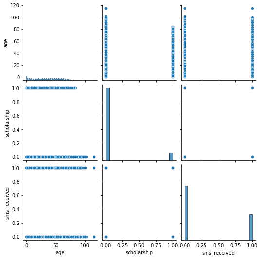

```python
# Visualizing the dataset above

sns.pairplot(df, height = 2.5)
```

## Exploratory Data Analysis

I've trimmed and cleaned my data, now ready to move on to exploration.

I will Compute statistics and present my visualizations with the goal of addressing the research questions posed in the Introduction section. I'm going to compute the relevant statistics throughout the analysis when an inference is made about the data.

### Research Question 1: What percentage of people showed up compared to those that didn't

```python
# Value counts function aggregates counts for each unique value in a column

df['no_show'].value_counts()
```

```
No     88207
Yes    22319
Name: no_show, dtype: int64
```

From the above result it was explained that the no_show represent data with 'No' if the patient was present for their appointment and 'Yes' if they were absent

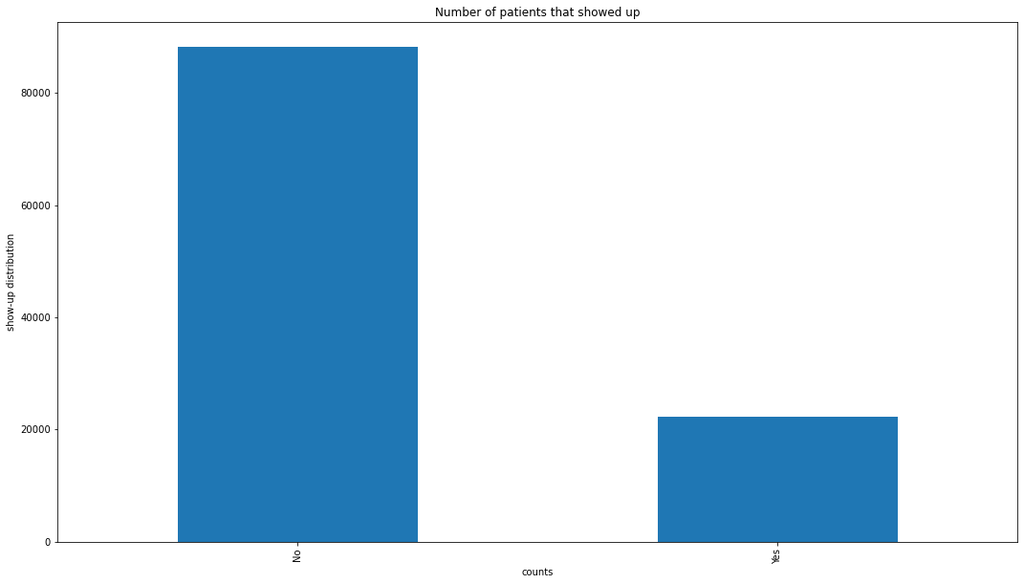

```python
# Checking the percentage of those that showed up and what percentage that didn't show up using a bar chart

Counts = df['no_show'].value_counts()
Counts.plot(kind = 'bar', figsize = (18,10))

plt.title('Number of patients that showed up')

plt.xlabel('counts')

plt.ylabel('show-up distribution')
```

```python
# Defining a percent function

def percent (value):
    percent = round(df[value].value_counts()/len(df)*100)
    return percent
```

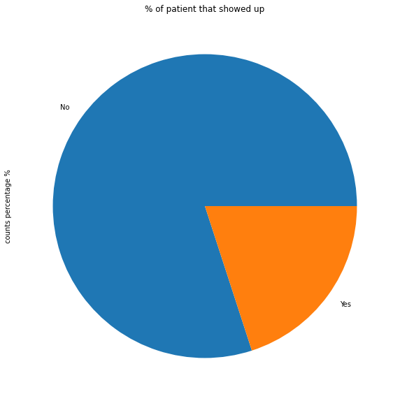

```python
 Using a pie chart to show the percentage of people that show up and didn't

value = percent('no_show')

value.plot(kind = 'pie', labels = ['No', 'Yes'], figsize = (18,10))

plt.ylabel('counts percentage %')

plt.title('% of patient that showed up')
```

So from the pie chart I observed 20% of patients didn't show up for their appointment.

I will need to carry out further investigation to understand the reason why the 20% didn't show for their doctor appointment

### Research Question 2: Why are people not showing up for their appointments?

We would need to analyze how each individual variable affects peoples ability to show up

Does scholarship affect the patient ability to show up for their appointment

```python
# Value counts function aggregates counts for each unique value in a column

df['scholarship'].value_counts()
```

```
0    99665
1    10861
Name: scholarship, dtype: int64
```

```python
# A Percentage is calculated by the mathematical formula of dividing the value by the sum of all the values and then multiplying the sum by 100

# Using the percent function done earlier

percent('scholarship')
```

```
0    90.0
1    10.0
Name: scholarship, dtype: float64
```

```python
# Creating a function to analyze the scholarship variable

def val(variable):
    chel = df[variable].value_counts()
    df1 = chel.plot(kind = 'bar', figsize = (12,8))
    plt.title("Count of Free Medicals")
    plt.ylabel("Counts")
    plt.xlabel("{}".format(variable))
    return df1
```

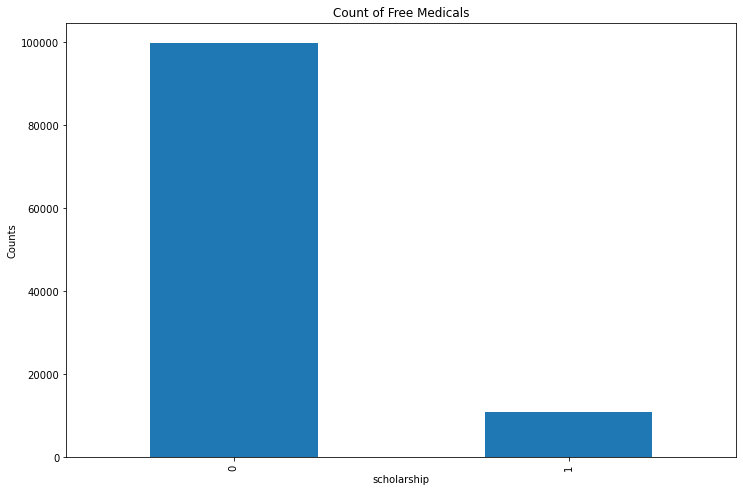

```python
# Analyze the scholarship variable with the function method

val('scholarship');
```

So using the bar chart above, we can deduce that only a few patient had access to scholarship.

We would need to analyze what percentage of patients got this scholarship and if it has any significant role in the patient's availability for their appointment

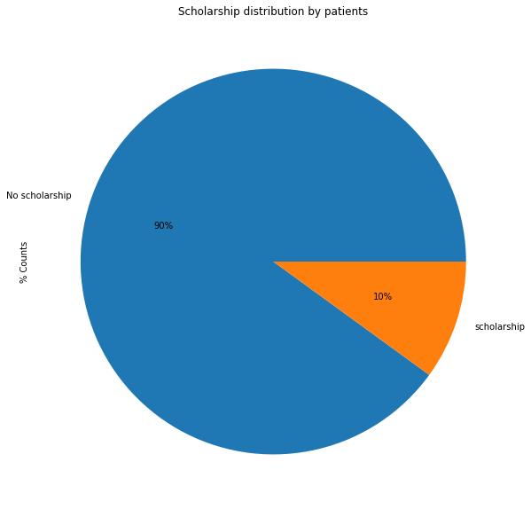

```python
# Further analysis on the scholarship parameter

value = percent('scholarship')
value.plot(kind = 'pie', labels = ['No scholarship', 'scholarship'], autopct = '%1.0f%%', figsize = (18,10))
plt.ylabel('% Counts')
plt.title("Scholarship distribution by patients")
```

We can see the percentage of the scholarship expressed in the pie chart

```python
# Using groupby method to unstack the value of the scholarship

df1 = df.groupby('scholarship')['no_show'].value_counts().unstack()
df1
```

| no_show scholarship | No | Yes |
| --- | --- | --- |
| 0 | 79924 | 19741 |
| 1 | 8283 | 2578 |

```python
# Detecting the scholarship percentage of the unstack

scholarship_percents = round(df.groupby('scholarship')['no_show'].value_counts()/len(df['scholarship'])*100).unstack()
scholarship_percents
```

| no_show scholarship | No | Yes |
| --- | --- | --- |
| 0 | 72.0 | 18.0 |
| 1 | 7.0 | 2.0 |

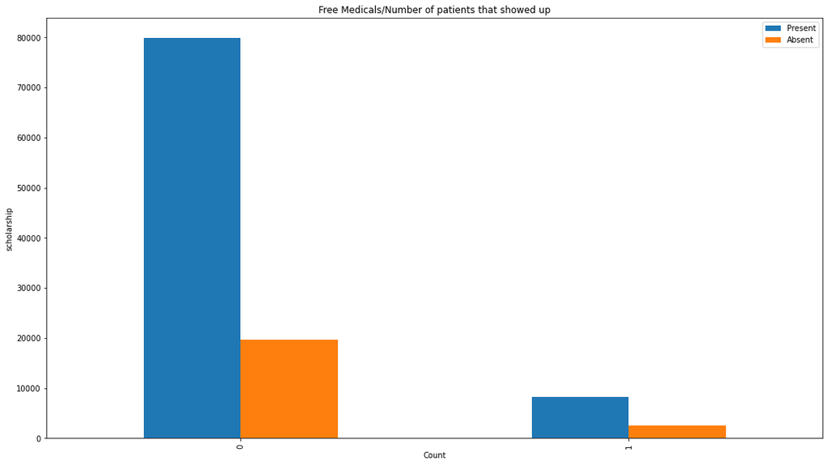

```python
# Creating a bar chart visualization showing the correlation between those on scholarship and does that aren't, those that came for appointment and those that didn't

df1 = df.groupby('scholarship')['no_show'].value_counts().unstack()
df1.plot(kind = 'bar', figsize = (18,10))
plt.title("Free Medicals/Number of patients that showed up")
plt.legend(['Present', 'Absent'])
plt.ylabel("scholarship")
plt.xlabel("Count")
```

### Research Question 3: Is there any significant relationship between distance from patient neighbourhood to the hospital and their showing up for appointments?

```python
#Let's start by checking the number of unique value in neighbourhood

df['neighbourhood'].nunique()
```

```
81
```

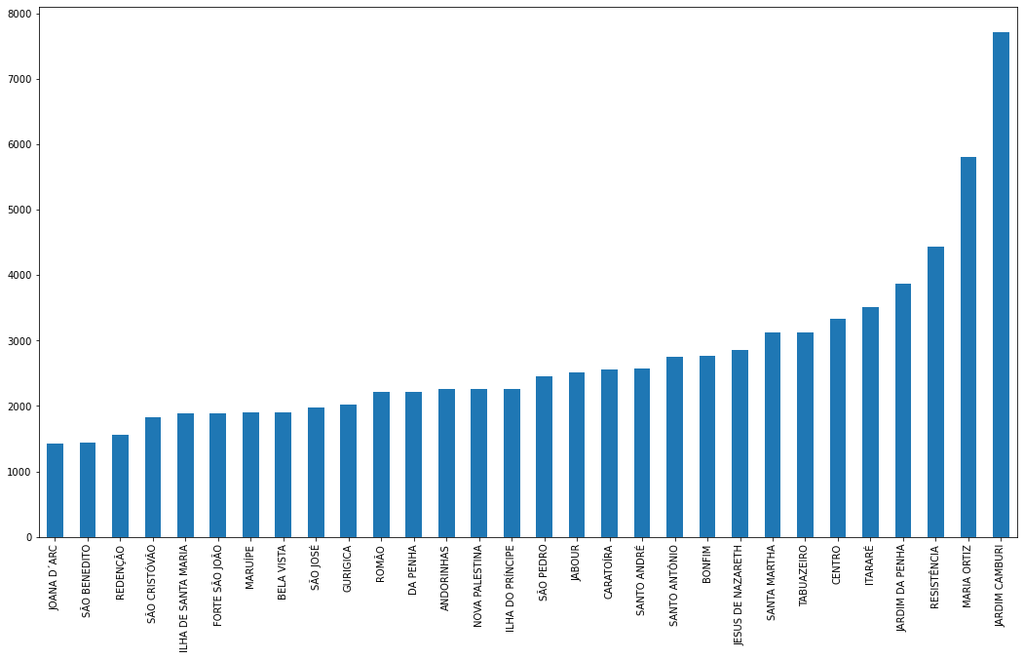

```python
# Using a bar chart to analyze the variable 'neighbourhood' using the first 30 records

df['neighbourhood'].value_counts().head(30).sort_values().plot(kind = 'bar', figsize=(18,10))
```

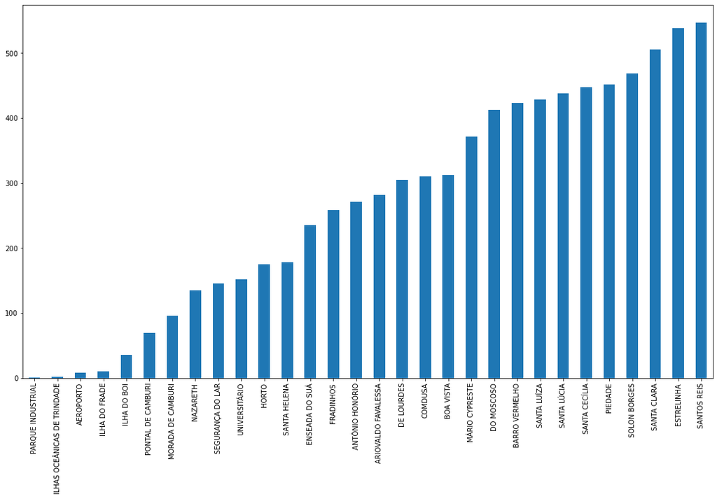

```python
# Using a bar chart to analyze the variable 'neighbourhood' using the last 30 records

df['neighbourhood'].value_counts().tail(30).sort_values().plot(kind = 'bar', figsize=(18,10))
```

```python
# Sorting through the neighbourhood variable

df1 = df.groupby('neighbourhood')['no_show'].value_counts().unstack().sort_values(by = 'No', ascending = False)
df1
```

| no_show neighbourhood | No | Yes |
| --- | --- | --- |
| JARDIM CAMBURI | 6252.0 | 1465.0 |
| MARIA ORTIZ | 4586.0 | 1219.0 |
| RESISTÊNCIA | 3525.0 | 906.0 |
| JARDIM DA PENHA | 3246.0 | 631.0 |
| SANTA MARTHA | 2635.0 | 496.0 |
| ... | ... | ... |
| ILHA DO BOI | 32.0 | 3.0 |
| ILHA DO FRADE | 8.0 | 2.0 |
| AEROPORTO | 7.0 | 1.0 |
| PARQUE INDUSTRIAL | 1.0 | NaN |
| ILHAS OCEÂNICAS DE TRINDADE | NaN | 2.0 |

81 rows × 2 columns

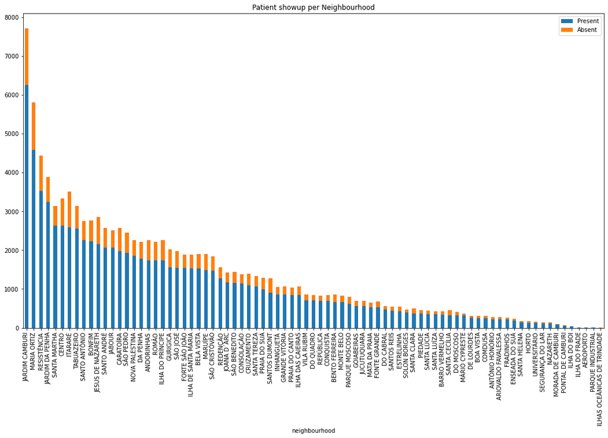

```python
df1 = df.groupby('neighbourhood')['no_show'].value_counts().unstack().sort_values(by = 'No',ascending = False)
df1.plot(kind = 'bar', stacked = True, figsize = (18,10))
plt.title('Patient showup per Neighbourhood')
plt.legend(['Present','Absent'])
```

We need more resources to determine the proximity between each neighbourhood and the health care facility.

There is no clear relationship between patient Neighbourhood and whether or not they will show up at the facility.

### Research Question 4: Any impact on the ability of a patient to show up for their appointment using time difference between a patient schedule date and his appointment date?

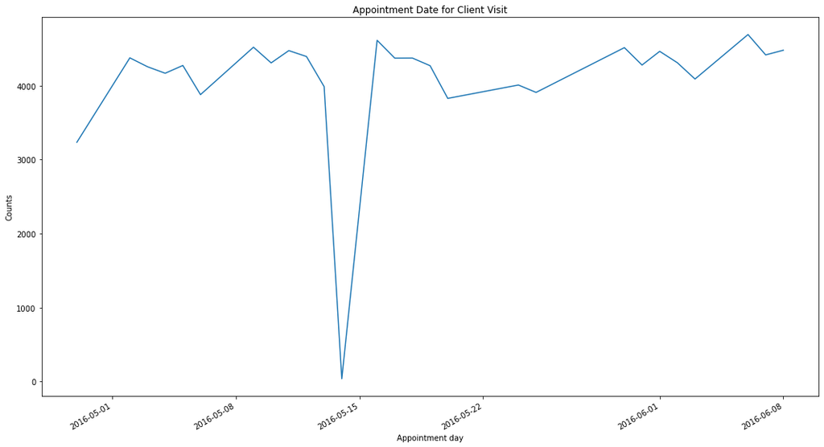

```python
# using visualization to analyze our parameter

df['appointment_day'].value_counts().plot(figsize = (18,10))

plt.xlabel('Appointment day')

plt.ylabel('Counts')

plt.title('Appointment Date for Client Visit')
```

```python
# Using groupby method to unstack the value of the appointment day

df1 = df.groupby('appointment_day')['no_show'].value_counts().unstack().sort_values(by = 'No',ascending = False)

df1.head(10)
```

| no_show appointment_day | No | Yes |
| --- | --- | --- |
| 2016-06-06 | 3818 | 873 |
| 2016-06-08 | 3705 | 774 |
| 2016-06-01 | 3652 | 812 |
| 2016-05-30 | 3626 | 888 |
| 2016-06-07 | 3600 | 816 |
| 2016-05-11 | 3589 | 885 |
| 2016-05-16 | 3564 | 1049 |
| 2016-05-12 | 3557 | 837 |
| 2016-05-02 | 3515 | 861 |
| 2016-05-31 | 3512 | 767 |

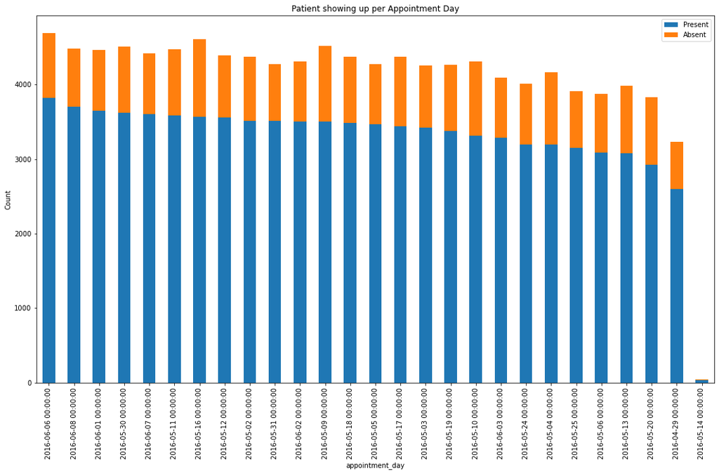

```python
# Using bar chart to draw up a correlation between patients showing up and the appointment day

df1.plot(kind = 'bar',  stacked = True, figsize = (18,10))

plt.title('Patient showing up per Appointment Day')

plt.legend(['Present','Absent'])

plt.ylabel('Count')
```

```python
# Getting the value count of scheduled days

df['scheduled_day'].value_counts()
```

```
2016-05-03    4238
2016-05-02    4216
2016-05-16    4120
2016-05-05    4095
2016-05-10    4024
              ...
2016-01-19       1
2016-04-09       1
2016-06-04       1
2016-01-26       1
2016-01-27       1
Name: scheduled_day, Length: 111, dtype: int64
```

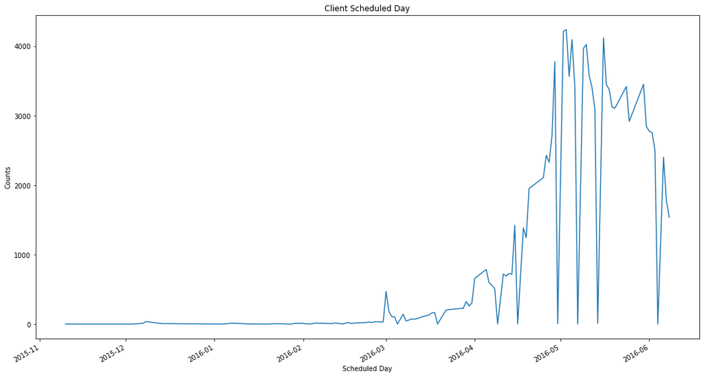

```python
# Creating a bar chart to show correlation between scheduled day and counts

df['scheduled_day'].value_counts().plot(figsize = (18,10))

plt.xlabel('Scheduled Day')

plt.ylabel('Counts')

plt.title('Client Scheduled Day')
```

```python
# Unstacking scheduled day and whether the patient showed or not

df1 = df.groupby('scheduled_day')['no_show'].value_counts().unstack().sort_values(by = 'No',ascending = False)

df1
```

| no_show scheduled_day | No | Yes |
| --- | --- | --- |
| 2016-05-02 | 3417.0 | 799.0 |
| 2016-05-16 | 3409.0 | 711.0 |
| 2016-05-03 | 3345.0 | 893.0 |
| 2016-05-05 | 3341.0 | 754.0 |
| 2016-05-10 | 3318.0 | 706.0 |
| ... | ... | ... |
| 2016-04-09 | 1.0 | NaN |
| 2015-11-10 | 1.0 | NaN |
| 2015-12-03 | NaN | 1.0 |
| 2016-01-04 | NaN | 1.0 |
| 2016-01-26 | NaN | 1.0 |

111 rows × 2 columns

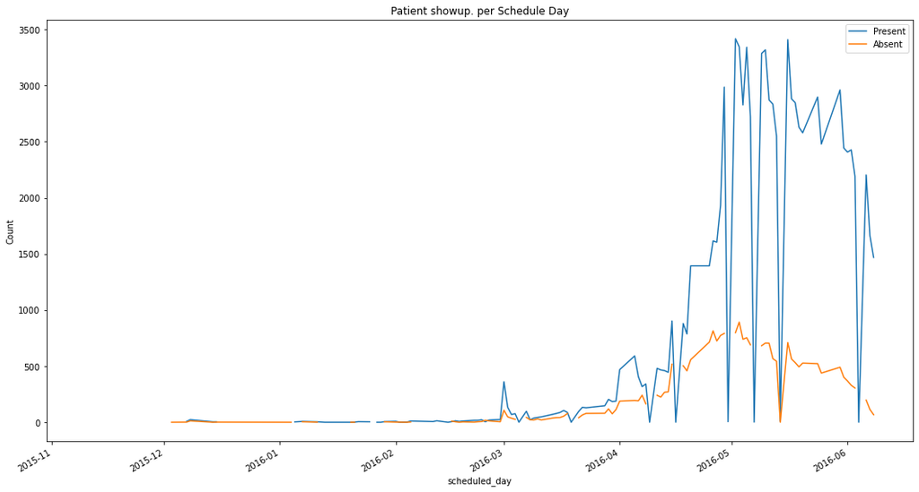

```python
# Using a line graph to correlate between counts and scheduled days

df1.plot(kind = 'line',  figsize = (18,10))

plt.title('Patient showup. per Schedule Day')

plt.legend(['Present','Absent'])

plt.ylabel('Count')
```

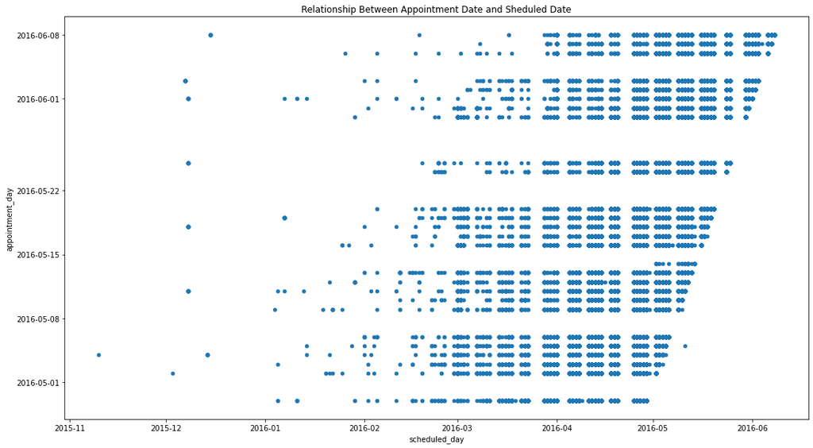

```python
#Relationship between Appointment Date and Schedule Date

df.plot(kind = 'scatter', x = 'scheduled_day', y ='appointment_day',figsize = (18,10))

plt.title('Relationship Between Appointment Date and Sheduled Date')
```

```python
# Getting the time differences between scheduled day and appointment day

df['Time_Diff'] = df['appointment_day']- df['scheduled_day']

df['Time_Diff'].value_counts().sort_values(ascending = False)
```

```
0 days      38562
2 days       6725
4 days       5290
1 days       5213
7 days       4906
            ...
127 days        1
126 days        1
117 days        1
-6 days         1
125 days        1
Name: Time_Diff, Length: 131, dtype: int64
```

```python
# Statistical values of the time diff

df['Time_Diff'].describe()
```

```
count                        110526
mean     10 days 04:24:39.789370826
std      15 days 06:07:14.979140739
min               -6 days +00:00:00
25%                 0 days 00:00:00
50%                 4 days 00:00:00
75%                15 days 00:00:00
max               179 days 00:00:00
Name: Time_Diff, dtype: object
```

```python
# using group by to determine if there is any relationship between the time difference and no show parameter

df1 = df.groupby('Time_Diff')['no_show'].value_counts().unstack().sort_values(by = 'No',ascending = False)

df1
```

| no_show Time_Diff | No | Yes |
| --- | --- | --- |
| 0 days | 36770.0 | 1792.0 |
| 2 days | 5123.0 | 1602.0 |
| 1 days | 4100.0 | 1113.0 |
| 4 days | 4059.0 | 1231.0 |
| 7 days | 3597.0 | 1309.0 |
| ... | ... | ... |
| 126 days | NaN | 1.0 |
| 132 days | NaN | 1.0 |
| 139 days | NaN | 1.0 |
| 146 days | NaN | 1.0 |
| 151 days | NaN | 1.0 |

131 rows × 2 columns

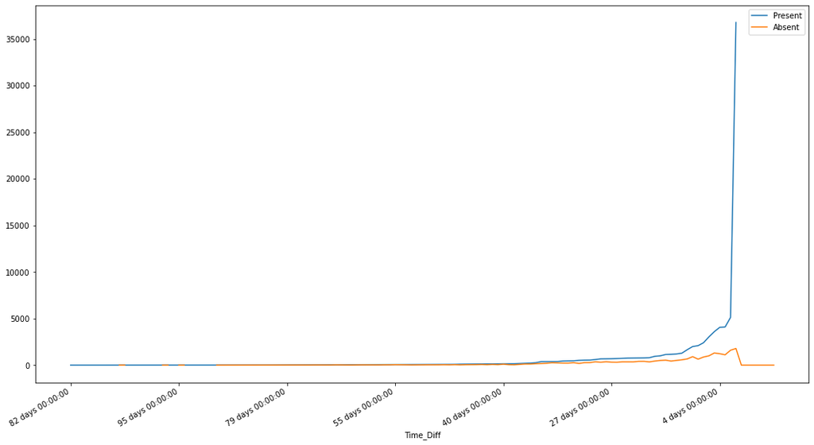

```python
# Graphical visualization of the relationship between the time difference and no show parameter

df1 = df.groupby('Time_Diff')['no_show'].value_counts().unstack().sort_values(by = 'No',ascending = True)

df1.plot(figsize = (18,10))

plt.legend(['Present','Absent'])
```

So Using the chart above, it shows that there is a direct relationship between waiting time and patients ability to show up.

Analyzing the difference between schedule and appointment shows that 25 percentile had the same day call up while some patient had to wait for as long as 179 days after scheduling an appointment.

It can be observed that those with shorter waiting time show up more than those with longer waiting time.

## Conclusions

So during my analysis of this dataset, I was able to come up with the following findings:

[output not shown]

## Limitations

```
1) If possible the hospital can help expand my analysis by providing more information on the major issue that prompt patients to book appointments

2) It looks like the data collection time is a bit too small to make predictions as regards patients no-show up factor.
```

```python
from subprocess import call
call(['python', '-m', 'nbconvert', 'Investigate_a_Dataset.ipynb'])
```

```
4294967295
```